# STA141A Milestone2: Decision-Making: Predictive Modeling of Mouse Behavioral Outcomes Using Integrated Neural Activity and Stimulus Features

Kefan Pan

2025-02-13

Abstract: This study analyzes neural recordings from mouse visual cortex during a decision-making task (Steinmetz et al., 2019) to predict trial outcomes (success/failure) Introduction:Neurodecoding technology can advance brain-computer interfaces and neurological disease research, with understanding how the brain makes decisions at its core.I use data from the Steinmetz team’s 2019 mouse experiments contains: Timing of visual cortex neuron firing over 400 milliseconds.Difference between left and right screen grayscales (0-1 gradient).Positive and negative feedback for each choice (success = 1, failure = -1). I aim to develop predictive models adapted to new experimental days and establish a scheme for integrating data across time.

Data Load

```r
library(tidyverse)
```

```r
library(ggplot2)
library(dplyr)
library(reshape2)
library(purrr)
library(knitr)
setwd("C:/Users/panke/Desktop/sessions")
files <- list.files(pattern = "\\.rds$")
sessions <- lapply(files, readRDS)
names(sessions) <- gsub("\\.rds$", "", files)
```

Data Summarize

```r
n.session <- length(sessions)

meta <- tibble(
  mouse_name = rep('name', n.session),
  date_exp = rep('dt', n.session),
  n_brain_area = rep(0, n.session),
  n_neurons = rep(0, n.session),
  n_trials = rep(0, n.session),
  success_rate = rep(0, n.session)
)
for (i in 1:n.session) {
  tmp <- sessions[[i]]
  meta[i, 1] <- tmp$mouse_name
  meta[i, 2] <- tmp$date_exp
  meta[i, 3] <- length(unique(tmp$brain_area))
  meta[i, 4] <- dim(tmp$spks[[1]])[1]
  meta[i, 5] <- length(tmp$feedback_type)
  meta[i, 6] <- mean(tmp$feedback_type == 1)
}
print(meta)
```

```
## # A tibble: 18 × 6
##    mouse_name date_exp   n_brain_area n_neurons n_trials success_rate
##    <chr>      <chr>             <dbl>     <dbl>    <dbl>        <dbl>
##  1 Cori       2016-12-14            8       734      114        0.605
##  2 Hench      2017-06-17           13      1172      447        0.620
##  3 Hench      2017-06-18            6       857      342        0.795
##  4 Lederberg  2017-12-05           12       698      340        0.738
##  5 Lederberg  2017-12-06           15       983      300        0.797
##  6 Lederberg  2017-12-07           10       756      268        0.694
##  7 Lederberg  2017-12-08            8       743      404        0.765
##  8 Lederberg  2017-12-09            6       474      280        0.718
##  9 Lederberg  2017-12-10            6       565      224        0.830
## 10 Lederberg  2017-12-11           10      1090      216        0.806
## 11 Cori       2016-12-17            5      1070      251        0.633
## 12 Cori       2016-12-18           11       619      228        0.662
## 13 Forssmann  2017-11-01           11      1769      249        0.667
## 14 Forssmann  2017-11-02           10      1077      254        0.661
## 15 Forssmann  2017-11-04            5      1169      290        0.741
## 16 Forssmann  2017-11-05            8       584      252        0.671
## 17 Hench      2017-06-15           15      1157      250        0.644
## 18 Hench      2017-06-16           12       788      372        0.685
```

```r
colnames(meta) <- c("Mouse Name", "Experiment Date", "Brain Areas", "Neurons", "Trials", "Success Rate")
kable(meta, format = "html", table.attr = "class='table table-striped'",digits=2, caption = "Summary of Experimental Sessions")
```

Summary of Experimental Sessions

| Mouse Name | Experiment Date | Brain Areas | Neurons | Trials | Success Rate |
| --- | --- | --- | --- | --- | --- |
| Cori | 2016-12-14 | 8 | 734 | 114 | 0.61 |
| Hench | 2017-06-17 | 13 | 1172 | 447 | 0.62 |
| Hench | 2017-06-18 | 6 | 857 | 342 | 0.80 |
| Lederberg | 2017-12-05 | 12 | 698 | 340 | 0.74 |
| Lederberg | 2017-12-06 | 15 | 983 | 300 | 0.80 |
| Lederberg | 2017-12-07 | 10 | 756 | 268 | 0.69 |
| Lederberg | 2017-12-08 | 8 | 743 | 404 | 0.76 |
| Lederberg | 2017-12-09 | 6 | 474 | 280 | 0.72 |
| Lederberg | 2017-12-10 | 6 | 565 | 224 | 0.83 |
| Lederberg | 2017-12-11 | 10 | 1090 | 216 | 0.81 |
| Cori | 2016-12-17 | 5 | 1070 | 251 | 0.63 |
| Cori | 2016-12-18 | 11 | 619 | 228 | 0.66 |
| Forssmann | 2017-11-01 | 11 | 1769 | 249 | 0.67 |
| Forssmann | 2017-11-02 | 10 | 1077 | 254 | 0.66 |
| Forssmann | 2017-11-04 | 5 | 1169 | 290 | 0.74 |
| Forssmann | 2017-11-05 | 8 | 584 | 252 | 0.67 |
| Hench | 2017-06-15 | 15 | 1157 | 250 | 0.64 |
| Hench | 2017-06-16 | 12 | 788 | 372 | 0.69 |

Summary: There exist success rate differences which suggesting differences in task performance across days or mice. Success rates may correlate with mouse experience or session difficulty.

create a matrix and combine information in each trail.

```r
i.s = 2
i.t = 1
spk.trial = sessions[[i.s]]$spks[[i.t]]
area=sessions[[i.s]]$brain_area
spk.count <- apply(spk.trial, 1, sum)
spk.average.tapply <- tapply(spk.count, area, mean)
tmp <- data.frame(area = area,spikes = spk.count)
spk.average.dplyr <- tmp %>%
  group_by(area) %>%
  summarize(mean = mean(spikes))

n.trial <- length(sessions[[i.s]]$feedback_type)
n.area <- length(unique(sessions[[i.s]]$brain_area))

trial.summary <- matrix(nrow = n.trial, ncol = n.area + 1 + 2 + 1)

average_spike_area <- function(i.t, this_session) {
  spk.trial <- this_session$spks[[i.t]]
  area <- this_session$brain_area
  spk.count <- apply(spk.trial, 1, sum)
  tapply(spk.count, area, mean)
}
this_session <- sessions[[i.s]]
for (i.t in 1:n.trial) {
  trial.summary[i.t, ] <- c(
    average_spike_area(i.t, this_session),
    sessions[[i.s]]$feedback_type[i.t],
    sessions[[i.s]]$contrast_left[i.t],
    sessions[[i.s]]$contrast_right[i.t],
    i.t
  )
}
colnames(trial.summary) <- c(
  names(average_spike_area(1, this_session = sessions[[i.s]])),
  "feedback", "left_contrast", "right_contrast", "id"
)
trial.summary <- as_tibble(trial.summary)
trial.summary <- na.omit(trial.summary)
print(trial.summary)
```

```
## # A tibble: 447 × 17
##      CA1    DG   GPe    MB   MRN   POL  POST  root   SCm  SCsg  VISl  VISp VISrl
##    <dbl> <dbl> <dbl> <dbl> <dbl> <dbl> <dbl> <dbl> <dbl> <dbl> <dbl> <dbl> <dbl>
##  1 0.816 0.836 0.730  1.57 0.833  1.31 0.927  1.83 1.65  0.263  1.54 0.876 0.456
##  2 0.658 0.699 0.460  1.29 0.889  1.12 0.951  3.64 0.609 0.158  1.60 0.695 0.265
##  3 0.855 0.932 0.794  1.74 0.764  1.07 0.976  2.03 0.913 0.368  1.42 1.23  0.544
##  4 0.908 0.932 0.762  1.30 0.958  1.40 0.634  2.25 0.826 0.158  1.56 1.03  0.441
##  5 0.816 0.712 0.698  1.58 0.708  1.38 0.732  1.25 0.739 0.474  1.44 0.981 0.426
##  6 0.592 0.726 0.635  1.47 0.819  1.23 1.07   1.67 0.826 0.421  1.45 0.943 0.324
##  7 0.974 1.05  0.984  1.91 0.958  1.55 1.24   2.39 2.35  0.947  1.81 1.46  0.544
##  8 0.737 0.945 0.857  1.55 0.944  1.45 0.854  1.81 1.48  0.632  1.77 1.12  0.360
##  9 1.20  1.15  1.02   1.64 1.28   1.60 1.15   2.25 1.48  1.05   1.73 1.2   0.618
## 10 0.658 0.877 0.905  1.70 0.778  1.26 1.07   2.11 1.48  1.05   1.58 1.2   0.353
## # ℹ 437 more rows
## # ℹ 4 more variables: feedback <dbl>, left_contrast <dbl>,
## #   right_contrast <dbl>, id <dbl>
```

Visualization

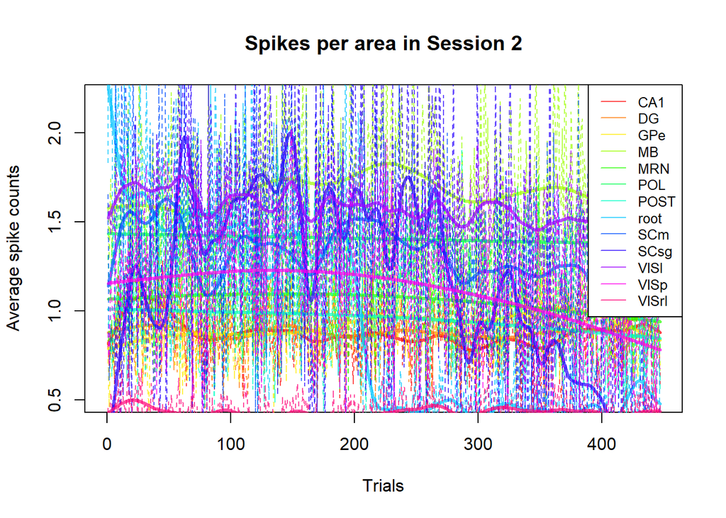

```r
area.col <- rainbow(n = n.area, alpha = 0.7)
plot(x = 1, y = 0, col = 'white',
     xlim = c(0, n.trial), ylim = c(0.5, 2.2),
     xlab = "Trials", ylab = "Average spike counts",
     main = paste("Spikes per area in Session", i.s))
for (i in 1:n.area) {
  lines(y = na.omit(trial.summary[[i]]), x = trial.summary$id[!is.na(trial.summary[[i]])], col = area.col[i], lty = 2, lwd = 1)
  lines(smooth.spline(trial.summary$id[!is.na(trial.summary[[i]])],na.omit(trial.summary[[i]])), col= area.col[i], lwd = 3)
}
legend("topright",
       legend = colnames(trial.summary)[1:n.area],
       col = area.col,
       lty = 1,
       cex = 0.8)
```

For this plot, we can find out peaks/troughs may correlate with trial outcomes (success/failure). And there exist some areas show consistently lower activity, while others exhibit higher variability, indicating functional specialization.

Data Integration

```r
integrated_data <- list()
for (i in 1:18) {
  session_data <- sessions[[i]]
  trials <- session_data$trials
  session_features <- lapply(trials, function(trial) {

    area_activity <- sapply(sessions, function(sessions) {
      neurons_in_area <- which(session_data$brain_area == area)
      mean(rowSums(trial$spks[neurons_in_area, ]))
    })
    data.frame(
      contrast_left = trial$contrast_left,
      contrast_right = trial$contrast_right,
      t(area_activity),
      feedback = trial$feedback_type
    )
  })
}
```